# Towards triaxial weaves using matrices

# Introduction

This document outlines progress towards and thinking about (re)implementing triaxial weaves using a matrix approach.

There are two major dimensions to this, if it is to parallel the approach to biaxial weaves:

1. An effective matrix representation of triaxial weaves
2. An approach to triangular grids compatible with the matrix representation

## Matrix and graph representations of triaxial weaves

Thinking on this has proceeded in two directions.

### A triaxial weave is really three independent biaxial weaves…

The insight (or hunch?) here is that a triaxial weave can be considered as three independent biaxial weaves. Each set of strands along two axes form a skewed biaxial weave, which could be implemented in the same way as biaxial weaves.

The logical part of this appears straightforward, and has been clarified by think about graph representations of weaves. There is limited literature on this, primarily

- Clapham CRJ. 1980. [When a Fabric Hangs together](https://dx.doi.org/10.1112/blms/12.3.161). *Bulletin of the London Mathematical Society* **12**(3)161–164.
- Clapham CRJ. 1985. When a three-way fabric hangs together. *Journal of Combinatorial Theory, Series B* **38**(2)190.

In a graph representation, each strand is a vertex in a digraph and where they cross the strand on top is the tail of an arc whose head points to the strand below. Since sets of parallel strands never cross, these form disjoint sets of nodes, and the graph structure is bipartite (biaxial weave) or tripartite (triaxial). Further, since every strand crosses every strand from any other set, the graph is an n-partite tournament. Some further thought clarifies that in a triaxial weave at most three strands can intersect at a location, and they can only have a non-cyclic set of arcs connecting them (one must be on top, one in the middle, and one on the bottom). [This is obvious but for a while was unclear due to muddled thinking about the fundamental unit in the grid.]

This leads to the following possible formulation of the function required

| A > B | B > C | C > A | Permutation |
| --- | --- | --- | --- |
| TRUE | TRUE | FALSE | ABC |
| TRUE | FALSE | FALSE | ACB |
| FALSE | TRUE | TRUE | BCA |
| FALSE | TRUE | FALSE | BAC |
| TRUE | FALSE | TRUE | CAB |
| FALSE | FALSE | TRUE | CBA |

This all seems reasonably clearcut.

The tricky part then is translating collapsing three biaxial weave matrices into a single triaxial matrix, which brings us to… ⎄

## Triangular grids

Triangular grids are more complicated than you think! And also less often used than orthogonal or hexagonal ones. The code in `weave-grids.R` implements an approach described in

- Nagy BN. 2003. [Shortest Paths in Triangular Grids with Neighbourhood Sequences](https://dx.doi.org/10.2498/cit.2003.02.04). *Journal of Computing and Information Technology* **11**(2)111.

Here it is in action

```r
source("weave-grids.R")
library(ggplot2)
library(stringr)
```

First make a grid generator with the requested number of axes (3 or 4) and spacing (this also supports a conventional orthogonal grid). This returns a function that will determine the x,y coordinates of a point based on its integer coordinates in the grid space.

```r
trigrid <- grid_generator(n_axes = 3, S = 100)
trigrid(c(1, 2, 3))
```

```
## [1]   57.73503 -100.00000
```

To see what we got, we can make a set of pts, which are the centre points of the grid cells.

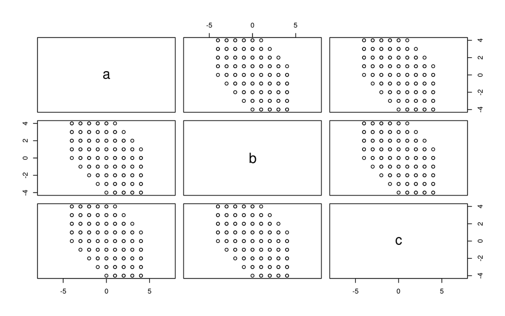

```r
coords <- expand.grid(a = -4:4, b = -4:4, c = -4:4) %>%
  mutate(parity = a + b + c) %>%
  filter(parity %in% 0:1) # only these coordinates exist in the grid
plot(coords[, 1:3], asp = 1)
```

Now make x, y coordinate space centres for each triangular grid cell. We can also show the coordinates as a label, and symbolise with a triangle.

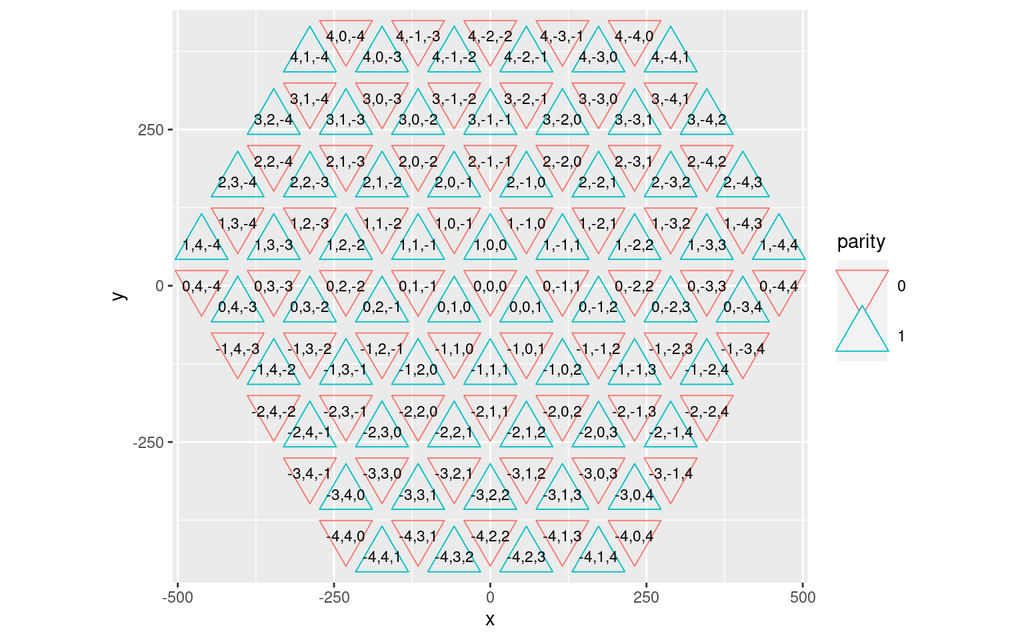

```r
pts <- apply(coords[, c("a", "b", "c")], 1, trigrid) %>% t() %>%
  data.frame() %>%
  as_tibble() %>%
  rename(x= X1, y = X2) %>%
  bind_cols(coords) %>%
  mutate(parity = as.factor(parity),
         label = paste(a, b, c, sep = ","))

ggplot(pts) +
  geom_point(aes(x = x, y = y, colour = parity, shape = parity), size = 10) +
  scale_shape_manual(values = c(6, 2)) + # up and down triangles
  geom_text(aes(x = x, y = y, label = label), size = 3) +
  coord_equal()
```

With a grid in place, the way is open to implementing a similar approach to triaxial weaves to that for biaxial, given code to generate triangles of appropriate dimension as ‘cells’. Prototype code below. Note that this just over plots the strands and isn’t figuring which is on top so as to hide lower strands etc.

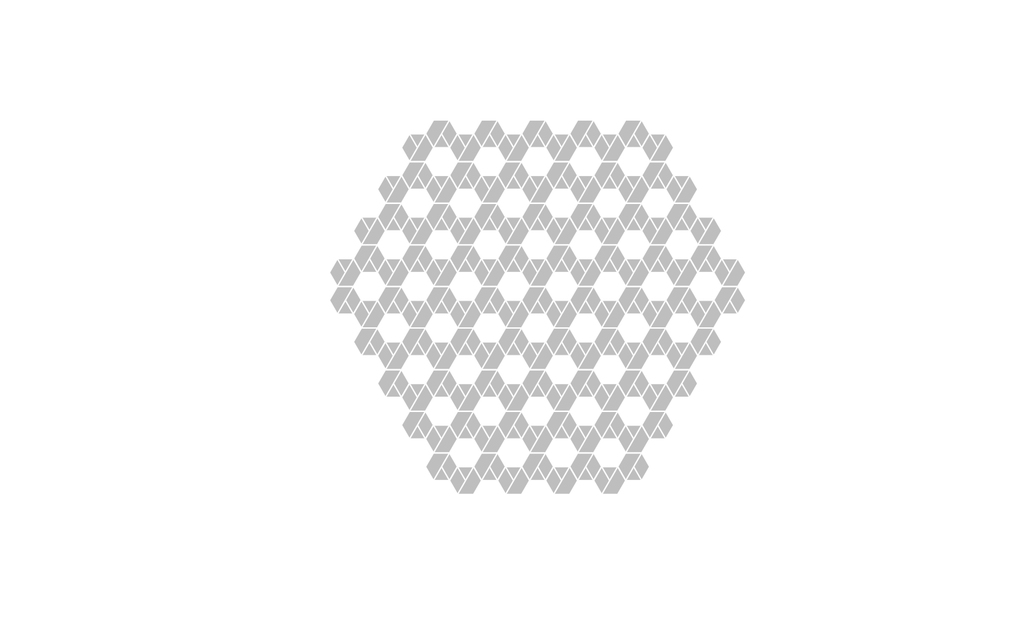

```r
cells <- list()
offsets <- as.matrix(pts[, c("x", "y")])
for (i in 1:nrow(offsets)) {
  o = ifelse(pts$parity[i] == 1, 0, 180)
  cells <- append(cells,
                  list(get_all_cell_strands(n = 3, S = 100, width = 0.333,
                                        orientation = o + 0:2 * 120) +
                         offsets[i, ]))
}
cells <- cells %>% sapply("[") %>% st_sfc() # this madness again...
cells %>% plot(border = "white", col = "grey")
```